# Stats 506 F20, Group Project

ARIMA models for Time-Series Data

Group 3: Zhilin He, Jialun Li, Chuwen Li

November 20, 2020

# Introduction

This project is a tutorial of using multivariate time series analysis for the stock market index, NIFTY 50 from NSE (National Stock Exchange) India. The data is obtained from [Nifty 50](https://www.kaggle.com/rohanrao/nifty50-stock-market-data) contains price history and trading volumes of fifty stocks in India from 2000-01-03 to 2020-09-30.

We illustrates how to using Python, R, and Stata to apply Auto Regressive Integrated Moving Average (ARIMA) to time series data. ARIMA is able to fit a given non-seasonal non-stationary time series based on its lag values. A general ARIMA model consists of three parts: the “AR” part means the variable of interest is regressed on its lag terms, the “I” part means the differenced values are used, and the “MA” part means the regression error is modeled as a linear combination of error terms in the past. The purpose of using differenced terms is to make the time series stationary for autoregression.

An ARIMA model is characterized by 3 terms: p (the order of AR term), q (the order of the MA term), and d (number of differencing to make time series stationary). Given a time series $\{X_t\}$, an $ARIMA(p, d, q)$ model can be expressed as:
$$(1-\sum_{i=1}^p\phi_iL^i)(1-L)^dX_t=
(1+\sum_{i=1}^q\theta_iL^i)\varepsilon_t + \delta$$
where $\varepsilon_t$ is the error term, $L$ is the lag operator, i.e. $LX_t = X_{t-1}, \forall t>1$, $p$ is the number of lagged terms of $X$, $d$ is the number of times of differencing needed for stationarity, $q$ is the number of lagged forecast errors in prediction, $\delta$ is the interception term for the regression, and $\theta, \phi$’s are the estimated regression coefficients.

ARIMA models are fitted in order to understand the data better and forecast future data. They are based on linear regression models. The best model can be chosen using AIC or BIC.

# Data cleaning and visualization

`NIFTY 50` data consist of 50 stocks, 230104 observations on 15 variables, including daily open, close, highest and lowest prices, volume and other relevant information for the “Nifty Fifty” stocks since January 2000. Detailed variable descriptions are shown in Table 1 below.

**Click to see variable descriptions.**

**Table 1**. *Varaibel descriptions of NIFTY 50 data*

| Variable Name | Variable Description |
| --- | --- |
| Date | Date of trade |
| Symbol | Name of the company |
| Series | We have only one series: Equity(EQ) |
| Prev Close | Previous day’s close price |
| Open | Open price of day |
| High | Highest price in day |
| Low | Lowest price in day |
| Last | Last traded price in day |
| Close | Close price of day |
| VWAP | Volume Weighted Average Price |
| Volume | A measure of sellers versus buyers of a particular stock |
| Turnover | The number of shares available for sale |
| Trades | The number of shares traded |
| Deliverable Volume | Shares which are actually transferred among demat accounts |
| %Deliverable | Percent of deliverble volume |
| Return | Return of trade |

As we are more interested in the stock prices, we use the variable `VWAP` for the most part. It can summarize the average price of the stock on a trading day. We want to catch the trend of stock prices across the years and possibly forecast future stock prices. Variable `Return` is newly created, which is the difference between `Close` and `Prev Close`.

Before conducting core analysis, let’s clean our data and check basic data structure.

```r
colnames(nifty)[colSums(is.na(nifty)) > 0]
```

```
[1] "Trades"             "Deliverable Volume" "%Deliverable"
```

As we can see, variables `Trade`, `Deliverable Volume`, and `%Deliverable` has missing values and we need to convert them to 0. Besides, we found out that there are stocks that changed its names during 2000 to 2020 period, so we need to bring their names into accord.

## Python

## R

```r
library(dplyr)
library(ggplot2)

# change old stock names to new
old_name = c('MUNDRAPORT', 'UTIBANK', 'BAJAUTOFIN', 'BHARTI', 'HEROHONDA',
       'HINDALC0', 'HINDLEVER', 'INFOSYSTCH', 'JSWSTL', 'KOTAKMAH', 'TELCO',
       'TISCO', 'UNIPHOS', 'SESAGOA', 'SSLT', 'ZEETELE')
new_name = c('ADANIPORTS', 'AXISBANK', 'BAJFINANCE', 'BHARTIARTL', 'HEROMOTOCO',
       'HINDALCO', 'HINDUNILVR', 'INFY', 'JSWSTEEL', 'KOTAKBANK', 'TATAMOTORS',
       'TATASTEEL', 'UPL', 'VEDL', 'VEDL', 'ZEEL')

nifty$Symbol = plyr::mapvalues(nifty$Symbol, from = old_name, to = new_name)

# summary statistics of variable of interest
nifty_clean = nifty %>%
  replace(is.na(.), 0) %>%
  mutate(Return = Close - `Prev Close`) %>%
  select(Date, Symbol, VWAP, Volume, Turnover, Return)
summary(nifty_clean)
```

```
      Date               Symbol               VWAP
 Min.   :2000-01-03   Length:230104      Min.   :    9.21
 1st Qu.:2006-05-23   Class :character   1st Qu.:  272.43
 Median :2011-06-07   Mode  :character   Median :  554.00
 Mean   :2011-02-20                      Mean   : 1224.17
 3rd Qu.:2016-02-05                      3rd Qu.: 1213.47
 Max.   :2020-09-30                      Max.   :32975.24
     Volume             Turnover             Return
 Min.   :        3   Min.   :1.047e+07   Min.   :-19525.95
 1st Qu.:   209105   1st Qu.:1.520e+13   1st Qu.:    -5.80
 Median :   973757   Median :6.400e+13   Median :     0.05
 Mean   :  2745270   Mean   :1.433e+14   Mean   :     0.25
 3rd Qu.:  2836929   3rd Qu.:1.710e+14   3rd Qu.:     6.40
 Max.   :481058927   Max.   :3.560e+16   Max.   :  2107.70
```

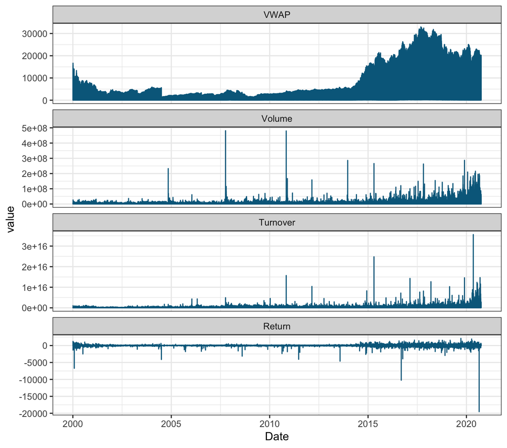

**Figure 1.** *Daily trend of all stocks, 2000-2020.*

```r
# plot trend of all stocks
fig.cap1 = "**Figure 1.** *Daily trend of all stocks, 2000-2020.*"

nifty_ts = reshape2::melt(nifty_clean[, -c(2)], id.vars = "Date")
ggplot(nifty_ts, aes(x = Date, y = value)) +
    geom_line(color= "deepskyblue4") +
    theme_bw() +
    facet_wrap(~ variable, scales = "free_y", ncol = 1)
```

From the trend of all stocks, we can see the time series of exhibit non-stationarity. There was a substantial strike to the India stock market after the outbreak of Coronavirus.

## Stata

# Core Analysis

## Python

## R

### ACF / PACF Plots

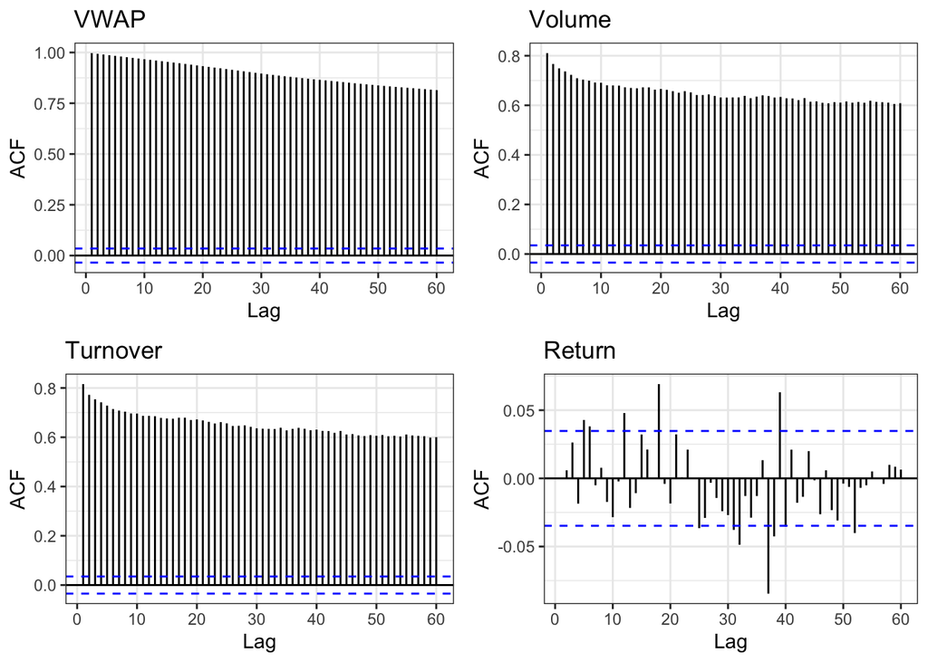

**Figure 2.** *ACF plots for stock: ADANIPORTS.*

```r
library(gridExtra)
library(forecast)

candidate = "ADANIPORTS"
vars_list = c("VWAP", "Volume", "Turnover", "Return")

nifty_cand = nifty_clean %>%
  filter(Symbol == candidate) %>%
  mutate_at(vars(matches(c("VWAP", "Volume", "Turnover"))), log)

# plot ACF
fig.cap2 = "**Figure 2.** *ACF plots for stock: ADANIPORTS.*"

acf_list = vector(mode = "list", length = length(vars_list))
names(acf_list) = vars_list
for ( var in vars_list ) {
  acf_list[[var]] = forecast::ggAcf(nifty_cand[[var]], lag.max = 60) +
    ggtitle(var) +
    theme_bw()
}

do.call("grid.arrange", c(acf_list, ncol = 2))
```

Notice that all the variables show high autocorrelation except for `Return`, which is because `Return` is calculated from the first difference of closing price working as a linear filter applied to eliminate a trend. Since we are going to apply ARIMA model to the data, which can only works for stationary time series, let’s take first difference of other three variables and compare the autocorrelation plot to the previous one. Later, we will apply `auto.arima()` function in R, which works for non-stationary time series by apply appropriate times of difference to detrend data.

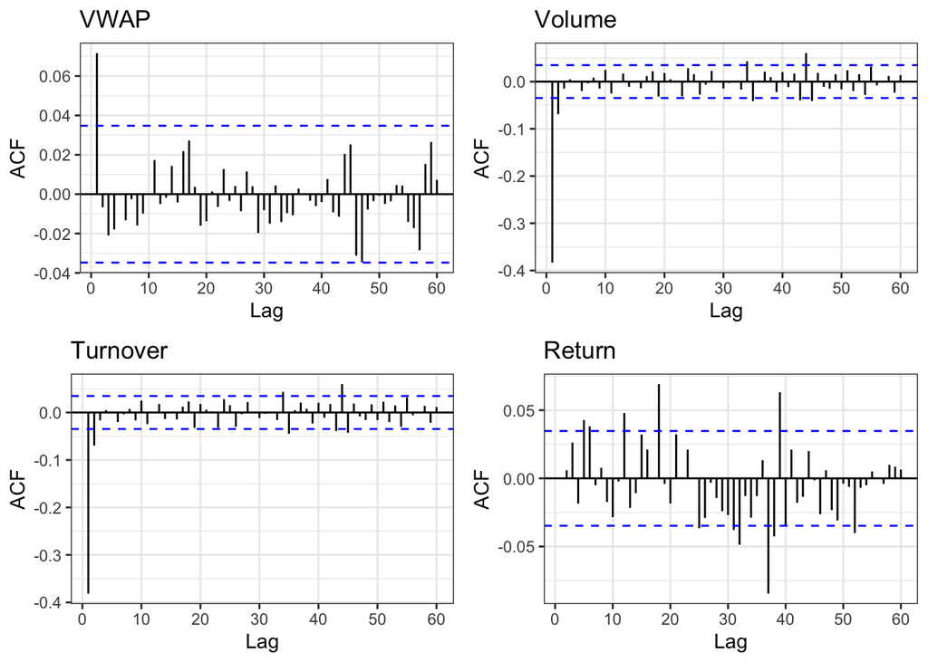

```r
fig.cap3 = paste("**Figure 3.** *ACF plots for stock: ADANIPORTS.*",
                 "VWAP, Volume, and Trades have taken first difference.")
do.call("grid.arrange", c(acf_diff_list, ncol = 2))
```

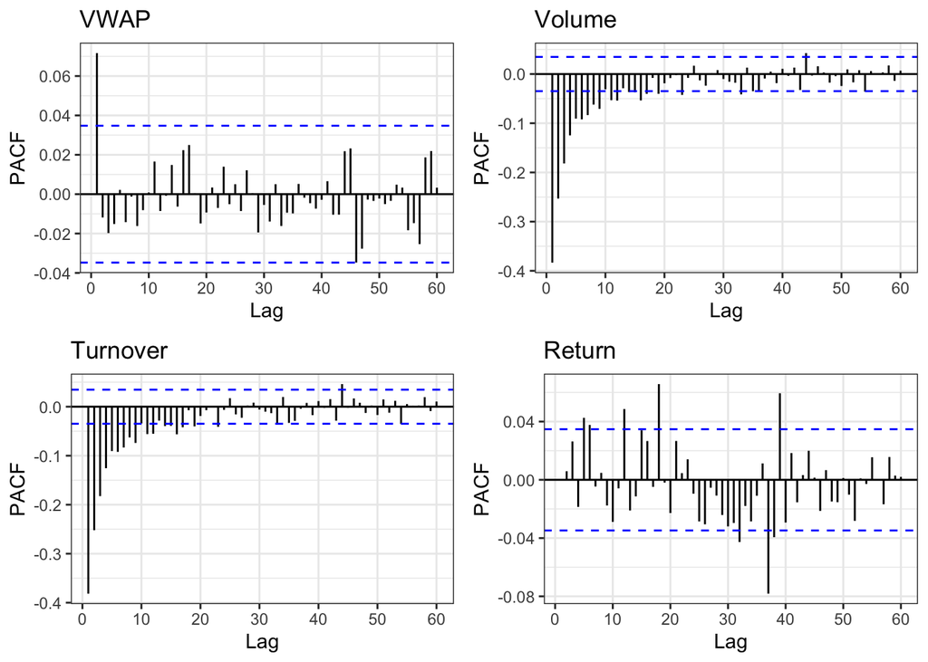

```r
fig.cap4 = paste("**Figure 4.** *PACF plots for stock: ADANIPORTS.*",
                 "VWAP, Volume, and Trades have taken first difference.")

do.call("grid.arrange", c(pacf_list, ncol = 2))
```

### Fitting an ARIMA Model

```r
aic_table = function(ts, P, Q, d){
  table = matrix(NA, (P + 1), (Q + 1))
  for(p in 0:P) {
    for(q in 0:Q) {
      table[p + 1, q + 1] <- arima(ts, order=c(p, d, q))$aic
    }
  }
  dimnames(table) = list(paste("AR", 0:P, sep = ""),
                          paste("MA", 0:Q, sep = ""))
  table
}

# Construct AIC table
nifty_cand_ts = ts(nifty_cand$Return, frequency = 1, start = c(2000, 01, 03))
nifty_aic_table = aic_table(head(nifty_cand_ts, -30), 4, 4, 0)

tab.cap2 = '**Table 2**. *AIC for different ARIMA parameters*'
nifty_aic_table %>%
  knitr::kable(format = 'html', caption = tab.cap2) %>%
  kableExtra::kable_styling('striped', full_width = TRUE)
```

**Table 2**. *AIC for different ARIMA parameters*

|  | MA0 | MA1 | MA2 | MA3 | MA4 |
| --- | --- | --- | --- | --- | --- |
| AR0 | 27514.98 | 27516.98 | 27518.81 | 27518.31 | 27518.78 |
| AR1 | 27516.98 | 27518.98 | 27520.96 | 27518.11 | 27519.28 |
| AR2 | 27518.83 | 27520.66 | 27514.92 | 27518.32 | 27477.74 |
| AR3 | 27517.96 | 27517.47 | 27478.51 | 27518.30 | 27520.65 |
| AR4 | 27518.41 | 27519.87 | 27518.41 | 27472.75 | 27514.69 |

The AIC table suggests that ARIMA(4, 0, 3) with the smallest AIC is the best model for the return of “ADANIPORTS”. This model may imply that increasing p and q will tend to get smaller AIC for a better fit. However, models with higher p and q are more complex, so it may lead to problems like overfitting, numerical stability and etc. We usually prefer a simply model, which also better for interpretation.

Even though it is nice to view the change of AIC value as the change of p and q, for a big data set like this, it is very inefficient to iterate over range of p and q. `auto.arima()`in the `forest` package is much faster in generating the results. It uses variant of Hyndman-Khandakar algorithm, which combines unit root test, minimizing AICc and MLE, and etc as evaluation criteria. `auto.arima()` on the training dataset for which the order specified is (4, 0, 2).

```r
ts_arima = auto.arima(head(nifty_cand_ts, -30), max.p = 4,
                      max.q = 4, max.d = 3)
print(ts_arima)
```

```
Series: head(nifty_cand_ts, -30)
ARIMA(4,0,2) with zero mean

Coefficients:
         ar1      ar2     ar3     ar4      ma1     ma2
      1.4754  -0.7572  0.0017  0.0138  -1.4765  0.7656
s.e.  0.2919   0.1707  0.0413  0.0362   0.2924  0.1669

sigma^2 estimated as 364.2:  log likelihood=-13751.28
AIC=27516.55   AICc=27516.59   BIC=27558.94
```

The return equation can be written as:
$$X_t = 1.475 X_{t-1}-0.757X_{t-2}+0.002X_{t-3}+0.014X_{t-4}
-1.477\varepsilon_{t-1}+0.766\varepsilon_{t-2}$$

### Model Diagnosis

```r
ts_forecasts = forecast(ts_arima, h = 30)
acc = accuracy(ts_forecasts, head(tail(nifty_cand_ts, 30), 7))
print(round(acc, 4))
```

```
                  ME    RMSE    MAE     MPE    MAPE   MASE    ACF1
Training set -0.0247 19.0664 6.8923     NaN     Inf 0.7046 -0.0016
Test set      0.4030  5.6660 4.8247 96.1783 96.1783 0.4933 -0.3315
             Theil's U
Training set        NA
Test set        0.8505
```

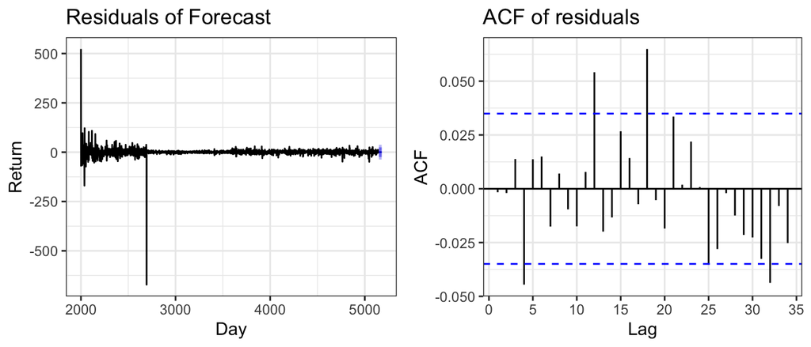

**Figure 5.** *Residual Diagnosis*

```r
fig.cap4 = "**Figure 5.** *Residual Diagnosis*"

p1 = autoplot(ts_forecasts, main = "") + xlab("Day") +
  ggtitle("Residuals of Forecast") +
  ylab("Return") +
  theme_bw()
p2 = ggAcf(resid(ts_arima)) + ggtitle("ACF of residuals") +
  theme_bw()

grid.arrange(p1, p2, ncol = 2)
```

Unfortunately, the residual plot does not appear normal. It suggests the result is heavily tailed. As the ARIMA model that we applied takes the MLE approach with moment assumptions, our data clearly do not hold the Gaussian distribution. ACF of residuals indicates that there is correlation in the residuals series. Thus, our model fails to account for all available information.

One way to imprve the model is to take log-transform of the data. A second way is to apply the ARIMA model that fits t-distributed errors without assuming Gaussian white noise. A third way is to use data segmentation that takes interventions into consideration, as stock data is often affected by government policy.

### Model Improvement

Let’s try to take log transformation for `Close` and `Prev Close` prior to calculating the `Return`.

```r
nifty_cand = nifty %>%
  filter(Symbol == candidate) %>%
  mutate_at(vars(matches(c("Close", "Prev Close"))), log) %>%
  mutate(Return = Close - `Prev Close`)

nifty_cand_ts = ts(nifty_cand$Return, frequency = 1, start = c(2000, 01, 03))

ts_log_arima = auto.arima(head(nifty_cand_ts, -30), max.p = 4,
                      max.q = 4, max.d = 3)

print(ts_log_arima)
```

```
Series: head(nifty_cand_ts, -30)
ARIMA(1,0,1) with zero mean

Coefficients:
          ar1     ma1
      -0.0951  0.0900
s.e.   2.7882  2.7899

sigma^2 estimated as 0.001757:  log likelihood=5521.64
AIC=-11037.29   AICc=-11037.28   BIC=-11019.12
```

`auto.arima()` suggests ARIMA(1, 0, 1) is the best fit for log returns.

[figure not shown]

**Figure 6.** *Residual Diagnosis of log returns.*

```r
fig.cap6 = "**Figure 6.** *Residual Diagnosis of log returns.*"

grid.arrange(p1, p2, ncol = 2)
```

We can see after taken the log transformation, there seems no significant correlation in the residuals series and variation of residuals stays very much the same apart from two outliers. Consequently, We can now be confident about model forecasts, which appears to account for all available information, but prediction intervals that are computed assuming a normal distribution may still be inaccurate.

## Stata

# Conclusion

# References

1. A modern Time Series tutorial: [Link](https://www.kaggle.com/rohanrao/a-modern-time-series-tutorial)
2. ARIMA model in Wikipedia: [Link](https://en.wikipedia.org/wiki/Autoregressive_integrated_moving_average)